# An Analysis on Factors Affecting Placement Status

Ilan Lipsky, Samuel Sawyer Todd, Tran Tran

| sl_no | gender | ssc_p | ssc_b | hsc_p | hsc_b | hsc_s | degree_p | degree_t | workex | etest_p | specialisation | mba_p | status | salary |
| --- | --- | --- | --- | --- | --- | --- | --- | --- | --- | --- | --- | --- | --- | --- |
| 1 | M | 67.00 | Others | 91.00 | Others | Commerce | 58.00 | Sci&Tech | No | 55.0 | Mkt&HR | 58.80 | Placed | 270000 |
| 2 | M | 79.33 | Central | 78.33 | Others | Science | 77.48 | Sci&Tech | Yes | 86.5 | Mkt&Fin | 66.28 | Placed | 200000 |
| 3 | M | 65.00 | Central | 68.00 | Central | Arts | 64.00 | Comm&Mgmt | No | 75.0 | Mkt&Fin | 57.80 | Placed | 250000 |
| 4 | M | 56.00 | Central | 52.00 | Central | Science | 52.00 | Sci&Tech | No | 66.0 | Mkt&HR | 59.43 | Not Placed | NA |
| 5 | M | 85.80 | Central | 73.60 | Central | Commerce | 73.30 | Comm&Mgmt | No | 96.8 | Mkt&Fin | 55.50 | Placed | 425000 |
| 6 | M | 55.00 | Others | 49.80 | Others | Science | 67.25 | Sci&Tech | Yes | 55.0 | Mkt&Fin | 51.58 | Not Placed | NA |

## Introduction

The “Campus Recruitment” dataset is a collection of data that measures the academic performance of students from secondary to college. It also provides basic demographics such as their gender, work experience, salary offered, degree type, and placement status.

Variables:

- sl_no: Serial number
- gender: Gender of the student (Male or Female)
- ssc_p: Secondary Education percentage (10th grade)
- ssc_b: Board of Education (Central/ Others)
- hsc_p: Higher Secondary Education percentage (12th grade)
- hsc_b: Board of Education (Central/ Others)
- hsc_s: Specialization in Higher Secondary Education (Science/ Commerce/Arts)
- degree_p: Degree Percentage
- degree_t: Undergraduate Degree Type (Sci&Tech/Comm&Mgmt/Other)
- workex: Work Experience (Yes/ No)
- etest_p: Employability test percentage (conducted by the college)
- specialisation: Post Graduate Specialization (Mkt&HR/Mkt&Fin)
- mba_p: MBA percentage
- status: Placement status (Not Placed/Placed)
- salary: Salary offered by corporate to candidates

The main question we are trying to answer using this dataset is:

What important factors influenced a candidate in getting recruited?

## What important factors influenced a candidate in getting recruited?

We will be using two different models and several graphs to answer this question and analyze our dataset. Namely we will be using logistic regression and random forest. First, we will start with logistic regression and use Stepwise algorithm to optimize the model. Afterward, we will start with random forest and use feature importance as well as hyper-parameters tuning to optimize the model. Both models will be using placement status as a response variable to compare and contrast which predictors are of significant for a candidate to be recruited.

## 1. Logistic Regression Model (Tran Tran)

### 1.1 Model Equation and Background

First we will build the model using all of the predictors variables except serial number and salary, because having a salary mean the candidate already recruited and including it will cause the result to be inaccurate interpretation.

Model equation:

$log(\frac{p}{1-p})=\beta_0 + \beta_1 * ssc_p + \beta_2 * ssc_b + \beta_3*hsc_p+\beta_4*hsc_b+\beta_5*hsc_s+\beta_6*degree_p+\beta_7*degree_t+\beta_8*workex+\beta_9*etest_p+\beta_{10}*specialisation+\beta_{11}*mba_p+\beta_{12}*gender+\epsilon$

$\beta_8$ = {0 if no, 1 if yes}

$\beta_{12}$ = {0 if male, 1 if female}

Using this model equation we will look over which predictors are of significant importance using the optimization method mentioned previously. Logistic regression was used because the response variable is categorical with a binary outcome, placed or not placed. Another reason is because this model less complex but still providing a good interpretability, which align with the goal for answering the project question. Unfortunately, logistic regression is more sensitive to outliers and overfitting compared to more complex models like random forest.

### 1.2 Logistic Regression Optimization

First I will run a summary report on the model with all of the predictors except salary as reasoned previously. Here I will look over which predictors are of statistical significant and I can see that ssc_p, hsc_p, degree_p, workex and mba_p P-values are less than 0.05, indicating that it is of significant to our response variable, the only one need further assessing is gender because its p-value is slightly higher than the common threshold.

```
Call:
glm(formula = status ~ . - salary, family = "binomial", data = college_df,
    maxit = 1000)

Coefficients: (3 not defined because of singularities)
                       Estimate Std. Error z value Pr(>|z|)
(Intercept)            19.47031    5.03022   3.871 0.000109 ***
gender                  1.19433    0.68598   1.741 0.081673 .
ssc_p                  -0.22891    0.04682  -4.889 1.01e-06 ***
hsc_p                  -0.10721    0.03778  -2.838 0.004541 **
degree_p               -0.18577    0.05558  -3.343 0.000830 ***
workex                 -2.08385    0.70839  -2.942 0.003264 **
etest_p                 0.01416    0.02266   0.625 0.532060
mba_p                   0.21413    0.05852   3.659 0.000253 ***
specialisation_Mkt_Fin -0.26381    0.55610  -0.474 0.635217
specialisation_Mkt_HR        NA         NA      NA       NA
ssc_b_Others           -0.22767    0.71685  -0.318 0.750787
hsc_b_Others           -0.33074    0.73509  -0.450 0.652757
hsc_s_Arts             -0.91121    1.45714  -0.625 0.531746
hsc_s_Commerce          0.58666    0.78080   0.751 0.452440
hsc_s_Science                NA         NA      NA       NA
degree_t_Comm_Mgmt     -1.11791    1.54778  -0.722 0.470132
degree_t_Sci_Tech       0.60785    1.67905   0.362 0.717337
degree_t_Others              NA         NA      NA       NA
---
Signif. codes:  0 ‘***’ 0.001 ‘**’ 0.01 ‘*’ 0.05 ‘.’ 0.1 ‘ ’ 1

(Dispersion parameter for binomial family taken to be 1)

    Null deviance: 266.771  on 214  degrees of freedom
Residual deviance:  99.677  on 200  degrees of freedom
AIC: 129.68

Number of Fisher Scoring iterations: 7
```

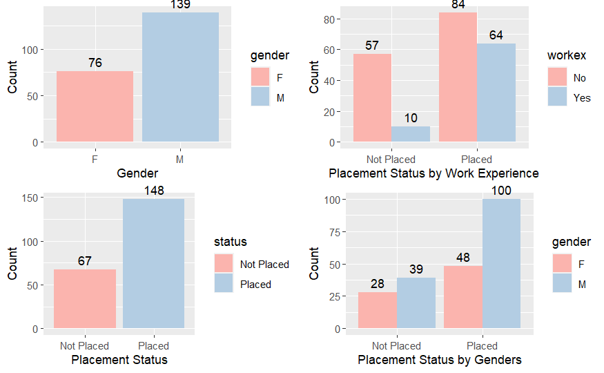

Looking over the count plots above, we can see that it matches some of the assumption that was found from the summary table. Placement status by genders for example, while at first seemingly skewed toward male students being favored, we have to remember the gender population in the dataset is 76 females vs 139 males, male students are nearly double females. The placement status by genders showed that there is bias against females student in proportion to the overall gender distribution in the dataset, and while it is not a large bias, I think it is still beneficial to include it in the final optimization result.

Now I will run the Stepwise algorithm which will progressively try to minimize the AIC and maximize the $R^2$ by removing and adding predictors to the model.

```r
table = step(college_glm_1, trace = 0 )
table
```

```
Call:  glm(formula = status ~ gender + ssc_p + hsc_p + degree_p + workex +
    mba_p + degree_t_Comm_Mgmt, family = "binomial", data = college_df,
    maxit = 1000)

Coefficients:
       (Intercept)              gender               ssc_p               hsc_p            degree_p              workex               mba_p  degree_t_Comm_Mgmt
           19.8021              1.2342             -0.2192             -0.1019             -0.1737             -2.3669              0.1986             -1.2587

Degrees of Freedom: 214 Total (i.e. Null);  207 Residual
Null Deviance:      266.8
Residual Deviance: 103.5    AIC: 119.5
```

The final result for the best optimization matched well with what we already saw through the summary table prior to running the step() function. With gender, ssc_p, hsc_p, degree_p, workex and mba_p being the best predictors for the model, but we also see degree_t_Comm_Mgmt being the extra predictor in the result despite its high P-value. This could be because while it is not of significant when combined with the initial all predictors run, it is in fact of significant when we run with this selected group of predictors instead.

### 1.3 Logistic Regression Results

The optimization process is finished, so I will now perform cross validation with 80% training and 20% testing sets.

```r
set.seed(41)
test_error = numeric(10)

for (i in 1:10) {
  sample_indices = sample.int(n = nrow(college_df), size = floor(0.8 * nrow(college_df)), replace = FALSE)
  train = college_df[sample_indices,]
  test = college_df[-sample_indices,]

  college_glm = glm(status ~ gender + ssc_p + hsc_p + degree_p + workex + mba_p + degree_t_Comm_Mgmt,
                     data = train,
                     family = "binomial")

  college_pred = predict.glm(college_glm, newdata = test, type = "response")
  yhat = ifelse(college_pred < 0.5, 'Not Placed', 'Placed')

  conf.test = table(test$status, yhat)
  test_error[i] = (conf.test[1, 2] + conf.test[2, 1]) / nrow(test)
}
mean(test_error)
```

```
[1] 0.1139535
```

The result is quite promising, with the average test error rate of only 11.40% for the logistic regression model.

```r
exams.glm2 = glm(status ~ gender + ssc_p + hsc_p + degree_p + workex + mba_p + degree_t_Comm_Mgmt,
                     data = train,
                     family = "binomial")
summary(exams.glm2)
```

```
Call:
glm(formula = status ~ gender + ssc_p + hsc_p + degree_p + workex +
    mba_p + degree_t_Comm_Mgmt, family = "binomial", data = train)

Coefficients:
                   Estimate Std. Error z value Pr(>|z|)
(Intercept)        17.67537    4.51247   3.917 8.97e-05 ***
gender              1.17240    0.62091   1.888 0.058999 .
ssc_p              -0.21353    0.04262  -5.010 5.43e-07 ***
hsc_p              -0.08233    0.03502  -2.351 0.018731 *
degree_p           -0.15468    0.05309  -2.914 0.003573 **
workex             -2.32904    0.72149  -3.228 0.001246 **
mba_p               0.18880    0.05391   3.502 0.000462 ***
degree_t_Comm_Mgmt -1.26663    0.61693  -2.053 0.040061 *
---
Signif. codes:  0 ‘***’ 0.001 ‘**’ 0.01 ‘*’ 0.05 ‘.’ 0.1 ‘ ’ 1

(Dispersion parameter for binomial family taken to be 1)

    Null deviance: 217.066  on 171  degrees of freedom
Residual deviance:  93.491  on 164  degrees of freedom
AIC: 109.49

Number of Fisher Scoring iterations: 6
```

## 2. Random Forest Model (Samuel Sawyer Todd, Ilan Lipsky)

### 2.1 Model Equation and Background

Next we will build the Random Forest using all of the predictors variables except serial number and salary, because having a salary means the candidate is already recruited, and including it will cause the result to be an inaccurate interpretation. Additionally, in contrast to Logistical Regression, Random Forest is robust to overfitting.

Model equation:

$status\sim\ gender + ssc\_p + ssc\_b + hsc\_p + hsc\_b + hsc\_s + degree\_p + degree\_t + workex + etest\_p + specialisation + mba\_p$

Using this model equation we will look over which predictors are of significant importance using variable importance plot. After converting the binary values to factors to ensure compatibility with the random forest algorithm, we split the data set into training and testing sets using the same fixed seed that was used for our Logistical Regression.

```r
library(randomForest)
library(randomForestExplainer)
library(caret)
library(magrittr)

# Convert binary variables to factors
college_df$gender <- as.factor(college_df$gender)
college_df$workex <- as.factor(college_df$workex)
college_df$status <- as.factor(college_df$status)

# Split the data into training and testing sets
set.seed(41)
sample_indices <- sample.int(n = nrow(college_df), size = floor(0.8 * nrow(-college_df)), replace = FALSE)
train_data <- college_df[sample_indices, ]
test_data <- college_df[-sample_indices, ]
```

We then utilize the randomForest function to train a random forest model in predicting admission status, excluding the “salary” variable. We can see in the MeanDecreaseGini plot graph of feature importance that “ssc_p”, “hsc_p”, “degree_p”, “mba_p”, “etest_p”, and “workex” are the most significant variables in predicting college admission status as they are nodes of the steepest drop curve.

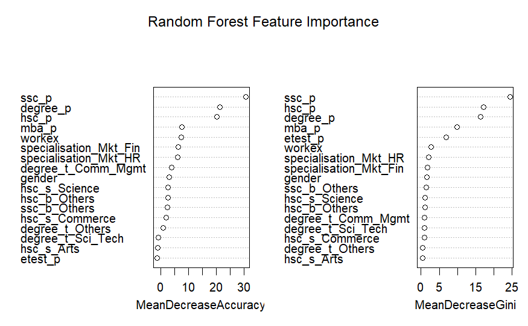

```r
# Train random forest model
rf_model_importance <- randomForest(status ~ . -salary, data = college_df, importance = TRUE)

# Plot feature importance
varImpPlot(rf_model_importance, main = "Random Forest Feature Importance")
```

Next, we rigorously test the trained Random Forest model by applying it to the designated test set, generating predictions that serve as a critical measure of its efficacy. To ensure consistency with the original status variable, the predicted values are converted into factors, maintaining alignment with the variable’s distinct levels. We then use this evaluation to compute our confusion matrix, which provides the detailed breakdown into the model’s accuracy, highlighting areas of strength and areas that may require refinement.

```r
# Make predictions on the test set
rf_pred <- predict(rf_model_importance, newdata = test_data)

# Convert predicted values to factors with the same levels as the original status variable
rf_pred <- factor(rf_pred, levels = levels(test_data$status))

# Confusion matrix
conf_matrix_rf <- confusionMatrix(data = rf_pred, reference = test_data$status)
print(conf_matrix_rf)
```

```
Confusion Matrix and Statistics

          Reference
Prediction  0  1
         0 28  0
         1  0 15

               Accuracy : 1
                 95% CI : (0.9178, 1)
    No Information Rate : 0.6512
    P-Value [Acc > NIR] : 9.742e-09

                  Kappa : 1

 Mcnemar's Test P-Value : NA

            Sensitivity : 1.0000
            Specificity : 1.0000
         Pos Pred Value : 1.0000
         Neg Pred Value : 1.0000
             Prevalence : 0.6512
         Detection Rate : 0.6512
   Detection Prevalence : 0.6512
      Balanced Accuracy : 1.0000

       'Positive' Class : 0
```

### 2.2 Random Forest Optimization

We attempted to use hyper-parameters for Random Forest optimization, however the default parameters were chosen as they are already optimized for the model. Therefore, we decided against updating the hyper-parameters.

### 2.3 Random Forest Results

Lastly, the following code showcases a more robust assessment of model performance using iterative evaluation over 10 splits and calculations of the mean test prediction error. The final mean test prediction error after 10 iterations is: 0.1511628.

```r
set.seed(41)
test_errors <- numeric(10)

for (iteration in 1:10) {
  sample_indices <- sample.int(n = nrow(college_df), size = floor(0.8 * nrow(college_df)), replace = FALSE)
  train_data <- college_df[sample_indices, ]
  test_data <- college_df[-sample_indices, ]

  rf_model <- randomForest(status ~ . -salary, data = train_data, importance = TRUE)

  rf_pred <- predict(rf_model, newdata = test_data)

  test_error <- mean(rf_pred != test_data$status)

  test_errors[iteration] <- test_error

  print(paste("Test Prediction Error for Test #", iteration, ":", test_error))
}
```

```
[1] "Test Prediction Error for Test # 1 : 0.209302325581395"
[1] "Test Prediction Error for Test # 2 : 0.13953488372093"
[1] "Test Prediction Error for Test # 3 : 0.13953488372093"
[1] "Test Prediction Error for Test # 4 : 0.186046511627907"
[1] "Test Prediction Error for Test # 5 : 0.0930232558139535"
[1] "Test Prediction Error for Test # 6 : 0.186046511627907"
[1] "Test Prediction Error for Test # 7 : 0.0930232558139535"
[1] "Test Prediction Error for Test # 8 : 0.13953488372093"
[1] "Test Prediction Error for Test # 9 : 0.0232558139534884"
[1] "Test Prediction Error for Test # 10 : 0.302325581395349"
```

```r
mean_test_error <- mean(test_errors)
print(mean_test_error)
```

```
[1] 0.1511628
```

## Bibliography

Roshan B. (April, 2020). Campus Recruitment. Retrieved September 30, 2023 from https://www.kaggle.com/datasets/benroshan/factors-affecting-campus-placement